# Reproducible Research: Peer Assessment 1

Daniel A Stearns

April 08, 2016

## Loading and preprocessing the data

#### 1. Load Libraries

```r
library(data.table)
library(chron)
```

#### 2. Load the data

```r
if(!file.exists('activity.csv')){
    unzip('activity.zip')
}

src_data <- read.csv("activity.csv")
```

#### 3. Review and the data set

```r
names(src_data)
```

```
## [1] "steps"    "date"     "interval"
```

```r
str(src_data)
```

```
## 'data.frame':    17568 obs. of  3 variables:
##  $ steps   : int  NA NA NA NA NA NA NA NA NA NA ...
##  $ date    : Factor w/ 61 levels "2012-10-01","2012-10-02",..: 1 1 1 1 1 1 1 1 1 1 ...
##  $ interval: int  0 5 10 15 20 25 30 35 40 45 ...
```

```r
summary(src_data)
```

```
##      steps                date          interval
##  Min.   :  0.00   2012-10-01:  288   Min.   :   0.0
##  1st Qu.:  0.00   2012-10-02:  288   1st Qu.: 588.8
##  Median :  0.00   2012-10-03:  288   Median :1177.5
##  Mean   : 37.38   2012-10-04:  288   Mean   :1177.5
##  3rd Qu.: 12.00   2012-10-05:  288   3rd Qu.:1766.2
##  Max.   :806.00   2012-10-06:  288   Max.   :2355.0
##  NA's   :2304     (Other)   :15840
```

```r
head(src_data)
```

```
##   steps       date interval
## 1    NA 2012-10-01        0
## 2    NA 2012-10-01        5
## 3    NA 2012-10-01       10
## 4    NA 2012-10-01       15
## 5    NA 2012-10-01       20
## 6    NA 2012-10-01       25
```

```r
tail(src_data)
```

```
##       steps       date interval
## 17563    NA 2012-11-30     2330
## 17564    NA 2012-11-30     2335
## 17565    NA 2012-11-30     2340
## 17566    NA 2012-11-30     2345
## 17567    NA 2012-11-30     2350
## 17568    NA 2012-11-30     2355
```

#### 4. Preprocess the data

```r
src_data$date <- as.Date(as.character(src_data$date),format="%Y-%m-%d")

data <- data.table(src_data)
data <- data[, weekday := weekdays(as.Date(date))]
data <- data[, daytype := ifelse(is.weekend(data$date), "Weekend", "Weekday") ]

data_day <- data[, list(steps = sum(steps, na.rm = T)), by = date]
data_int <- data[, list(steps = mean(steps, na.rm = T)), by = interval]
data_cleansing_strategy <- data[, list(mean_steps = mean(steps, na.rm = T)), by =  list(interval,weekday)]
tables()
```

```
##      NAME                      NROW NCOL MB
## [1,] data                    17,568    5  1
## [2,] data_cleansing_strategy  2,016    3  1
## [3,] data_day                    61    2  1
## [4,] data_int                   288    2  1
##      COLS                                KEY
## [1,] steps,date,interval,weekday,daytype
## [2,] interval,weekday,mean_steps
## [3,] date,steps
## [4,] interval,steps
## Total: 4MB
```

## What is mean total number of steps taken per day?

#### 1. Display Total Steps per Data

```r
data_day
```

```
##           date steps
##  1: 2012-10-01     0
##  2: 2012-10-02   126
##  3: 2012-10-03 11352
##  4: 2012-10-04 12116
##  5: 2012-10-05 13294
##  6: 2012-10-06 15420
##  7: 2012-10-07 11015
##  8: 2012-10-08     0
##  9: 2012-10-09 12811
## 10: 2012-10-10  9900
## 11: 2012-10-11 10304
## 12: 2012-10-12 17382
## 13: 2012-10-13 12426
## 14: 2012-10-14 15098
```

[output cut: 48 more lines]

#### 2. Plot Historgram of total steps per day

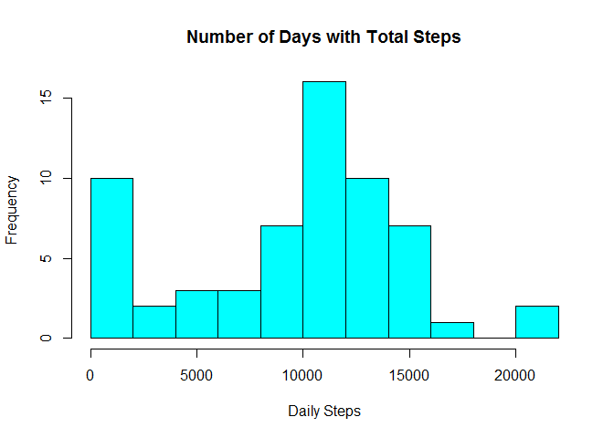

```r
hist(
   data_day$steps,
   breaks=15,
   main="Number of Days with Total Steps",
   xlab="Daily Steps",
   ylab="Frequency",
   col="cyan"
)
```

```r
#barplot(
#    data_day$steps,
#    names=data_day$date,
#    main="Total Steps Per Day",
#    xlab="Dates",
#    ylab="Steps",
#    col="cyan",
#    cex.names=0.6
#)
```

```r
median_daily_steps <- median(data_day[,steps])
mean_daily_steps <- mean(data_day[,steps])
```

## What is the average daily activity pattern?

#### 1. Time series plot of the interval and steps taken.

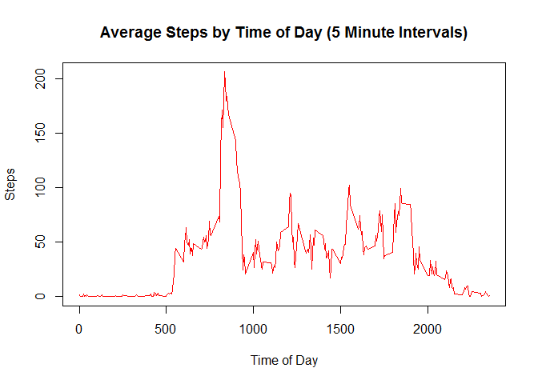

```r
plot(
    data_int$interval,
    data_int$steps,
    type='l',
    col="red",
    main="Average Steps by Time of Day (5 Minute Intervals)",
    xlab="Time of Day",
    ylab="Steps"
)
```

#### 2. Which 5-minute interval, on average across all the days in the dataset, contains the maximum number of steps?

```r
max_step_interval <- data_int[which.max(data_int$steps)]$interval
```

##### Interval with Maximum Steps: 835

## Inputing missing values

#### 1. Calculate Missing Values

```r
total_missing <- sum(is.na(data$steps))
```

##### Total Missing Values: 2304

#### 2. Devise a strategy for filling in all of the missing values in the dataset. The strategy does not need to be sophisticated. For example, you could use the mean/median for that day, or the mean for that 5-minute interval, etc.

Reviewing the data set we find we are missing 13.1% of the step values from the dataset.We would like to devise strategy for imputing the missing values, since the mean and median strategies are not the best options, I choose to create a strategy tha generates the mean value for steps based on the weekday and interval. I felt the weekday was an important factor as people have diffrent habits based on days of the week. If more data was present I may have also looked at seasonality of the steps. For example Fall, Winter, Spring, Summer. The imputed value is then applied to the NA values in the dataset where matched on the weekday and interval.

```r
data_clean <- data
data_clean <- merge(data_clean, data_cleansing_strategy, by=c("interval","weekday"))
data_clean <- within(data_clean, steps <- ifelse(is.na(steps), mean_steps, steps))
data_clean <- data_clean[ ,list(date, interval, steps, daytype)]


#verify there are no missing values
sum(is.na(data_clean$steps))
```

```
## [1] 0
```

#### 3. Create a new dataset that is equal to the original dataset but with the missing data filled in.

```r
data_clean_day <- data_clean[, list(steps = sum(steps, na.rm = T)), by = date]
```

#### 4. Plot Historgram of total steps per day

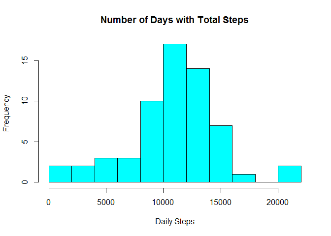

```r
hist(
   data_clean_day$steps,
   breaks=15,
   main="Number of Days with Total Steps",
   xlab="Daily Steps",
   ylab="Frequency",
   col="cyan"
)
```

```r
#barplot(
#    data_clean_day$steps,
#    names=data_clean_day$date,
#    main="Total Steps Per Day",
#    xlab="Dates",
#    ylab="Steps",
#    col="cyan",
#    cex.names=0.6
#)
```

```r
median_clean_daily_steps <- median(data_clean_day[,steps])
mean_clean_daily_steps <- mean(data_clean_day[,steps])
```

## Are there differences in activity patterns between weekdays and weekends?

#### 1. Create a new factor variable

```r
date_week <- data_clean
data_week <- data[, list(steps = mean(steps, na.rm = T)), by = list(interval, daytype)]
data_weekday <- data_week[daytype=="Weekend"]
data_weekend <- data_week[daytype=="Weekday"]
```

#### 2. Make a panel plot

[figure not shown]

```r
par(mfrow=c(2,1))

plot(
    data_weekend$interval,
    data_weekend$steps,
    type='l',
    col="red",
    main="Average Steps by Time of Day (5 Minute Intervals)

    Weekend",
    xlab="Time of Day",
    ylab="Steps",
    ylim=c(0, 250)
)

plot(
    data_weekday$interval,
    data_weekday$steps,
    type='l',
    col="red",
    main="Weekday",
    xlab="Time of Day",
    ylab="Steps",
    ylim=c(0, 250)
)
```

#### 3. Weekend/Weekday Differences

```r
summary(data_weekday$steps)
```

```
##    Min. 1st Qu.  Median    Mean 3rd Qu.    Max.
##   0.000   1.107  32.040  43.080  75.570 175.000
```

```r
summary(data_weekend$steps)
```

```
##    Min. 1st Qu.  Median    Mean 3rd Qu.    Max.
##   0.000   2.218  23.970  35.340  51.870 234.100
```